# Philadelphia Weather Data Analysis

[Fan Li](https://www.linkedin.com/in/fanli)

February 22, 2015

## Data Preparation

We will use historical weather data of Philadelphia[^1] in this demo. The script for data parsing and transformation can be found in R/import_weather.data.R.

Randomly select 10 rows for examination:

| Month | Day | Year | HighTemp | LowTemp | Precipitation | Snow |
| --- | --- | --- | --- | --- | --- | --- |
| 6 | 23 | 1910 | 95 | 75 | 0.00 | 0.0 |
| 1 | 8 | 1932 | 47 | 38 | 0.58 | 0.0 |
| 12 | 26 | 1946 | 49 | 23 | 0.00 | 0.0 |
| 10 | 22 | 1948 | 56 | 36 | 0.00 | 0.0 |
| 5 | 30 | 1956 | 79 | 54 | -0.01 | 0.0 |
| 3 | 21 | 1958 | 38 | 33 | 0.07 | 0.4 |
| 4 | 6 | 1959 | 58 | 46 | -0.01 | 0.0 |
| 7 | 9 | 1962 | 89 | 69 | -0.01 | 0.0 |
| 5 | 12 | 1973 | 74 | 51 | 0.10 | 0.0 |
| 11 | 25 | 1977 | 44 | 34 | 0.46 | 0.0 |

The data files have seven columns[^2]:

- Columns 1, 2 and 3 contain the month, day, and year.
- Columns 4 and 5 are the daily high and low temperatures (in oF).
- Column 6 is the daily precipitation in inches (rain plus melted snow).[^3]
- Column 7 is the daily snowfall, in inches.[^4]

## Basic Operators

#### select(data, col.1, col.2, …)

Select/keep only the variables you mention. For example, if we are interested in the daily snowfall, we can create a subset of the data this way:

```r
# This is the same as weather[c("Year", "Month", "Day", "Snow")] but a little cleaner.
snowfall <- select(weather, Year, Month, Day, Snow)
kable(head(snowfall))  # Create a html table
```

| Year | Month | Day | Snow |
| --- | --- | --- | --- |
| 1872 | 1 | 1 | NA |
| 1872 | 1 | 2 | NA |
| 1872 | 1 | 3 | NA |
| 1872 | 1 | 4 | NA |
| 1872 | 1 | 5 | NA |
| 1872 | 1 | 6 | NA |

#### filter(data, condition.1, condition.2, …)

Because snowfall data prior to 1885 is missing, we will remove them from the analysis. We can also limit our analysis to Feburary as well.

```r
# This is the same as subset(snowfall, Year >=1885 & Month == 2)
snowfall <- filter(snowfall, Year >= 1885, Month == 2)
kable(head(snowfall))
```

| Year | Month | Day | Snow |
| --- | --- | --- | --- |
| 1885 | 2 | 1 | 0.3 |
| 1885 | 2 | 2 | 0.5 |
| 1885 | 2 | 3 | 0.4 |
| 1885 | 2 | 4 | 0.0 |
| 1885 | 2 | 5 | 0.0 |
| 1885 | 2 | 6 | -0.1 |

#### arrange(data, col.1, col.2, …)

```r
snowfall <- arrange(snowfall, -Snow, -Year)
kable(head(snowfall))
```

| Year | Month | Day | Snow |
| --- | --- | --- | --- |
| 1983 | 2 | 11 | 21.1 |
| 1979 | 2 | 19 | 13.9 |
| 1978 | 2 | 6 | 12.4 |
| 1902 | 2 | 17 | 11.0 |
| 1900 | 2 | 17 | 10.0 |
| 1899 | 2 | 13 | 10.0 |

#### group_by() + summarize()

Now, which Feburary is the most “snowy” month?

```r
feb.snow <- arrange(
                summarize(
                    group_by(snowfall, Year),
                    Snow.Sum = sum(Snow, na.rm = TRUE)
                ),
                -Snow.Sum, -Year
            )
kable(head(feb.snow))
```

| Year | Snow.Sum |
| --- | --- |
| 1899 | 31.4 |
| 1979 | 27.0 |
| 1983 | 26.0 |
| 1907 | 23.9 |
| 1978 | 18.8 |
| 1934 | 18.2 |

So far the syntax difference from the core R may look trivial. However the dplyr way has several advantages:

- It appears cleaner and will give you more meaningful error message if anything goes wrong.
- Its standardized, SQL-like operators (verbs) makes data manipulation easier to think.
- Many core functions were written in C++ and have great speed gain versus standard R (to be discussed later).
- It can communicate with many data storage backends besides dataframe (to be discussed later).

Note: If the basic operators cannot meet your need, you can also use the do(.) operator to directly access the grouped data.

## Pipe and Chaining

#### Pipe operator (%>%)

All above operators (and other operators in dplyr) take a dataframe as the first argument (input), followed by other parameters, and produce a dataframe as output.

The “%>%” operator was designed to “pipes” data or function output into the subsequent function and therefore convert nested structures into cleaner and more logical chain expressions.

```r
data %>% function()  # equal to function(data)

foo() %>% bar()      # equal to bar(foo())
```

Therefore, the following chain can create the same “snowy” feburary dataset as shown above.

```r
feb.snow2 <- weather %>%
  select(Year, Month, Day, Snow) %>%                 # Step 1. Select relevant variables
  filter(Year >= 1885, Month == 2) %>%               # Step 2. Filter by year and month
  group_by(Year) %>%                                 # Step 3. Group by year
  summarize(Snow.Sum = sum(Snow, na.rm = TRUE)) %>%  # Step 4. Summarize monthly snowfall
  arrange(-Snow.Sum, -Year)                          # Step 5. Sort table by monthly snowfall/year

kable(head(feb.snow2))
```

| Year | Snow.Sum |
| --- | --- |
| 1899 | 31.4 |
| 1979 | 27.0 |
| 1983 | 26.0 |
| 1907 | 23.9 |
| 1978 | 18.8 |
| 1934 | 18.2 |

#### Chaining

The chain operator also works with almost all other functions which takes a dataframe as the first argument. For example, we may pipe transformed data directly into ggplot to compare daily temperature between 1880 and 2000.

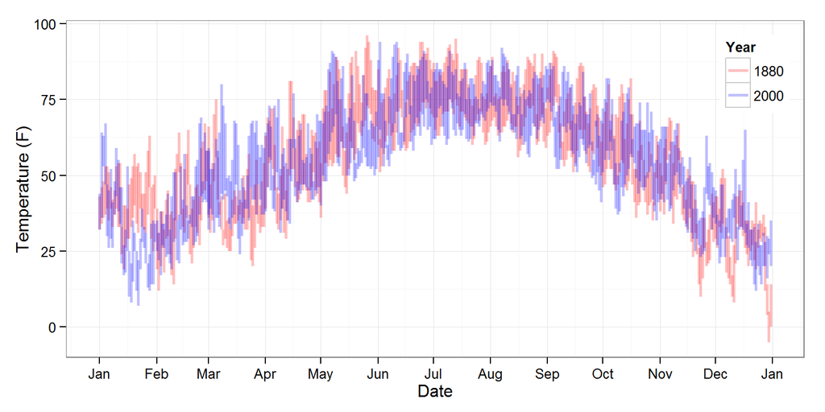

```r
weather %>%
  filter(Year %in% c(1880, 2000)) %>%  # Data available from 1874
  mutate(Date = as.Date(ymd(paste(1234, Month, Day))),
         Year = as.factor(Year)) %>%
  select(Year, Date, HighTemp, LowTemp) %>%
  ggplot() +
  geom_linerange(aes(x = Date, ymax = HighTemp, ymin = LowTemp, color = Year), alpha = 0.25, na.rm = TRUE, size = 1) +
  scale_x_date(breaks = "1 month",  labels = date_format("%b")) +
  scale_y_continuous(name="Temperature (F)") +
  scale_color_manual(values = c("red", "blue")) +
  theme_bw() +
  theme(legend.justification=c(1,1), legend.position=c(1,1))
```

## Data Backends

#### Working with SQL database

As a trival example, we will convert our weather dataset into a RDB with RSQLite package.

```
## [1] TRUE
```

Next, we can directly working on this database through src_sqlite() in dplyr.

```r
weather.db <- src_sqlite("../data/weather.sqlite") %>%
  tbl("weather") %>%
  select(Year, Month, Day, Snow) %>%                 # Step 1. Select relevant variables
  filter(Year >= 1885, Month == 2) %>%               # Step 2. Filter by year and month
  group_by(Year) %>%                                 # Step 3. Group by year
  summarize(Snow.Sum = sum(Snow)) %>%  # Step 4. Summarize monthly snowfall
  arrange(-Snow.Sum, -Year)

# Show result via collect()
kable(head(collect(weather.db)))
```

| Year | Snow.Sum |
| --- | --- |
| 1899 | 31.4 |
| 1979 | 27.0 |
| 1983 | 26.0 |
| 1907 | 23.9 |
| 1978 | 18.8 |
| 1934 | 18.2 |

```r
# Show SQL query
explain(weather.db)
```

```
## <SQL>
## SELECT "Year", "Snow.Sum"
## FROM (SELECT "Year", SUM("Snow") AS "Snow.Sum"
## FROM "weather"
## WHERE "Year" >= 1885.0 AND "Month" = 2.0
## GROUP BY "Year") AS "_W1"
## ORDER BY  - "Snow.Sum",  - "Year"
##
##
## <PLAN>
##   selectid order from                       detail
## 1        0     0    0           SCAN TABLE weather
## 2        0     0    0 USE TEMP B-TREE FOR GROUP BY
## 3        0     0    0 USE TEMP B-TREE FOR ORDER BY
```

#### Working with mutiple data sources

| Date | HighTemp | LowTemp |
| --- | --- | --- |
| 1/1/2000 | 50 | 27 |
| 1/2/2000 | 54 | 34 |
| 1/3/2000 | 64 | 42 |
| 1/4/2000 | 62 | 39 |
| 1/5/2000 | 46 | 21 |
| 1/6/2000 | 36 | 19 |

```r
weather %>%
  transmute(Date = ymd(paste(Year, Month, Day)),
            Philly.High = HighTemp, Philly.Low = LowTemp) %>%
  inner_join(
    boston %>%
      transmute(Date = mdy(Date), Boston.High = HighTemp, Boston.Low = LowTemp),
    by = "Date"
  ) %>%
  head() %>%
  kable()
```

| Date | Philly.High | Philly.Low | Boston.High | Boston.Low |
| --- | --- | --- | --- | --- |
| 2000-01-01 | 44 | 32 | 50 | 27 |
| 2000-01-02 | 64 | 36 | 54 | 34 |
| 2000-01-03 | 63 | 53 | 64 | 42 |
| 2000-01-04 | 67 | 47 | 62 | 39 |
| 2000-01-05 | 47 | 30 | 46 | 21 |
| 2000-01-06 | 45 | 26 | 36 | 19 |

[^1]: http://learn.fi.edu/weather/data2/
[^2]: http://learn.fi.edu/weather/data2/
[^3]: Originally in 1/100 inches. Converted to inches for clarity
[^4]: Originally in 1/10 inches. Converted to inches for clarity
[^5]: http://www.wunderground.com/history/airport/KBOS/2015/2/23/DailyHistory.html